# Student Growth: The Pulse of the Education System

DoWEA Fall Leadership Meeting · Executive Learning Session

Damian W. Betebenner

National Center for the Improvement of Educational Assessment

October 26–30, 2026

## A brief introduction

DB

**Damian W. Betebenner, Ph.D.**

National Center for the Improvement of Educational Assessment

- Developer of the Student Growth Percentile methodology — the Colorado Growth Model — now used by education systems across the United States
- Author of the `SGP` R package, the open implementation of that work
- Adviser to states and large systems on using growth, not only achievement, for performance management

The views today are mine. They are offered as a conversation with DoWEA leadership, not as an audit of DoWEA schools.

## How this session is organized

1. **What student growth is about** — a picture, not a formula
2. **Death to proficiency. Long live proficiency.** — why status alone is a poor management tool
3. **Norm and criterion** — how much did they grow, and is it enough?
4. **DoWEA status and growth** — NAEP achievement, and a first look at cohort growth
5. **Growth for process management** — finding pockets of strength and weakness
6. **Questions**

AI systems assisted in preparing this deck. Every number is tied to a cited public source or to labeled illustrative data. Responsibility for the claims remains with the author.

# What student growth is about

## Status: snapshots in time

## Growth: learning between the snapshots

Learning is a process.  
Education is the system designed to support it.  
Student growth is how we know whether that system is working.

# Death to proficiency. Long live proficiency.

## Status-based systems are poor performance-management tools

We live in a culture that loves **ends** and neglects **means**.

- I want to be successful.
- I want to win.
- I want proficiency rates to go up.

Accountability systems built on a single status number ask schools to produce an outcome without describing the process that produces it.

The management error

Telling a school to “raise proficiency” is like telling a team to “win more.” It names the scoreboard. It does not name the work.

## What sports teach about accountability

- A coach is judged on wins and losses. That will not change.
- Good coaches do not tell players to “win more.” They install a process.
- If everyone plays their role, the team has the best chance of winning.
- In education, wins and losses are proficient and not proficient.
- “Raise proficiency rates” is the forced shot — an ill-advised play, written as policy.

## The rational, maladaptive response

Focus on the bubble kids.

A status-only scoreboard makes it rational to spend the year on students just below the cut. That is the educational version of the forced shot. It can move the number. It is not a process for learning.

## Wear two hats

**Hat 1 — Accountability.** Proficiency is what you are ultimately responsible for. A system where few students are proficient is not healthy, whatever else is true.

**Hat 2 — Management.** Effective performance management focuses on process. That is the hat you wear on Tuesday morning.

[figure not shown]

## Growth and status are opposite sides of the same coin

Where a student is today depends on **where they started** and **how quickly they traveled**.

Distance = Rate × Time

- **Growth** is the leading indicator — the rate
- **Status** is the lagging indicator — the distance

If you care about achievement, you already care about growth. You may not be watching it yet.

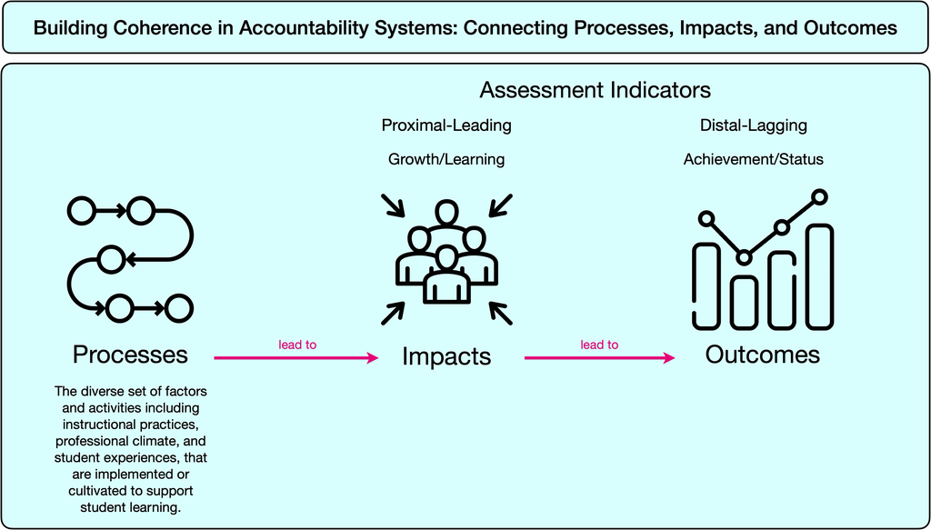

# Norm and criterion

## Two ways of understanding the world

[figure not shown]

## An inch is not always an inch

[figure not shown]

## A complete understanding requires both

**Norm-referenced.** Where does this observation sit in a distribution of similar observations?

**Criterion-referenced.** Where does this observation sit relative to a standard we care about?

For student growth

**How much did the student grow?** — among academic peers.

**Is it enough?** — relative to a proficient (or college-ready, or on-track) standard.

## Student Growth Percentiles: how much did they grow?

## Percentile growth trajectories: is it enough?

[figure not shown]

## Growth and system status

[figure not shown]

# DoWEA status and growth

## DoWEA students are high achieving

[figure not shown]

## The gap is not only the average

[figure not shown]

## Steady through the pandemic years

[figure not shown]

DoWEA held steady from 2017 to 2024 while national averages fell. That is a status success. It still does not answer whether students are **learning a lot**.

Our students are high achieving.  
But are they learning a lot?

## How to read a growth number from NAEP

NAEP does not follow the same students from Grade 4 to Grade 8. It takes two snapshots of different samples from the same cohort — here, Grade 4 in 2015 and Grade 8 in 2019, mathematics.

Recent work with Professor Henry Braun estimates **cohort growth** from those two snapshots. It borrows the link between Grade 4 and Grade 8 scores from states that do follow individual students.

The result is a **mean SGPc**: the average growth percentile of a jurisdiction’s students against **national academic peers**.

A mean of 50

The jurisdiction’s students progressed, on average, as their national peers did from the same Grade 4 starting points.

**DoWEA: 54.1** — seventh of 52 jurisdictions, in the **very high** group. On average, DoWEA students finished Grade 8 at the 54th percentile of national peers who started Grade 4 in the same place. (NAEP reports DoWEA as DoDEA.)

## DoWEA growth among the highest in the nation

[figure not shown]

## High status and high growth

[figure not shown]

## One level up: the United States internationally

[figure not shown]

Same question, same cohort years, one level up: among education systems, U.S. growth is **typical**, near the international middle.

## Comparisons require a common test

Each step up trades local fit for wider comparison.

International assessment

**TIMSS.** Compares the United States with other countries.

National assessment

**NAEP.** Compares every participating jurisdiction — DoWEA, each state, and the nation.

Consortium assessment

**Smarter Balanced and similar.** Compares the members that share the test.

Unique assessment

**DoWEA CCRS summative (grades 3–7).** Compares DoWEA schools and students with one another.

DoWEA’s CCRS summative assessments are the right instrument **inside** the system. NAEP is the bridge **across** states; TIMSS is the bridge **across** countries.

# Growth for process management

## Same proficiency, different learning

Illustrative data — not DoWEA results

[figure not shown]

## Pockets of strength and weakness

Illustrative data — not DoWEA results

[figure not shown]

## Region, then district, then school

Illustrative data — not DoWEA results

[figure not shown]

## Are the highest achievers still learning a lot?

Illustrative data — not DoWEA results

[figure not shown]

Status can look excellent while students who already sit high are coasting — or while students who sit low are not catching up.

## Watch the process, not a single year

Illustrative data — not DoWEA results

[figure not shown]

## Questions a process-minded system asks

Not: *Who do we blame?*

Instead:

1. Where is growth strong — and what is happening there?
2. Where is growth weak for students who already sit high?
3. Where is growth weak for students who need to catch up?
4. What will we try, and how will we know in a year?

DoWEA already has the language

The 2026 Blueprint for Continuous Improvement is a process document. Growth is the pulse that tells you whether the blueprint is being felt in classrooms.

## Three things to leave with

1. **Proficiency is the destination.** It is what the public — and you — are responsible for. It is a poor tool for managing the work week to week.
2. **Growth is the pulse.** It tells you whether the process that produces proficiency is working — for students who start behind and for students who start ahead.
3. **DoWEA’s status is not in doubt.** The first NAEP evidence on cohort growth is encouraging. The operational work is to watch growth **inside** the system, school by school, with the assessments you already give.

## Questions

**Damian W. Betebenner**  
dbetebenner@nciea.org

National Center for the Improvement of Educational Assessment

These slides: [dbetebenner.github.io/DoWEA_Presentation_102626](https://dbetebenner.github.io/DoWEA_Presentation_102626/)

NAEP growth work with **Professor Henry I. Braun**, Lynch School of Education, Boston College.

[figure not shown]